# Homework - Deer collisions

Matt Ring

2021-10-24

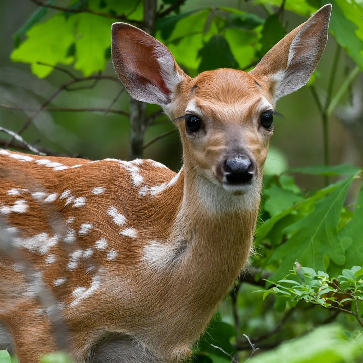

**Due date**: Monday October 25th, 2021 any time before class

**Points available**: 10

## Context

Deer-vehicle collisions in the United States are responsible for an average of 200 human deaths and over a billion dollars of property damage per year. In this exercise, you will explore real data associated with deer-vehicle collisions in the state of Virginia.

### Data files

- **Wildlife Vehicle Collisions**: VACollisions.csv; collected as latitude and longitude with EPSG = 4326.
- **National Land Cover Dataset (NLCD)** from 2016 for part of Virginia: NLCD_2016_partVA.tiff
- **Virginia County Boundaries**: VirginiaCounty.shp

```r
library(sf)
```

Data is extracted from the zipped file in the R Script using the code below.

```r
# unzip data folder

unzip(
  zipfile =  'data/raw/homework_data_deer_collisions.zip',
  exdir = 'data/raw')
```

Shapefiles and raster files are imported and set to the same CRS.

```r
# open data files

va_land_cover <-
  raster::raster('data/raw/homework_data_deer_collisions/nlcd2016.tif')

va_shp <-
  st_read('data/raw/homework_data_deer_collisions/VirginiaCounty.shp') %>%
  st_transform(
    crs = st_crs(va_land_cover))
```

### Output

1. **[1 point]** In the va_collisions.csv file, remove zero value coordinates and repair erroneous coordinates (e.g., coordinates outside of the state of Virginia).

Imports the data as a tibble, converts flipped coordinates (lat/long to long/lat), filters for missing values, then finally converts to a Simple Features object and subsets by locations within the shapefile.

```r
# 1. Remove and fix zero and erroneous coordinates from the csv file

va_collisions <-
  read.csv("data/raw/homework_data_deer_collisions/va_collisions.csv") %>%
  as_tibble() %>%
  mutate(x_temp =     # Finds then flips reversed lat/lon values
           ifelse(x > 0, y, x),
         y_temp =
           ifelse(y < 0, x, y)) %>%
  mutate(x = x_temp,
         y = y_temp) %>%
  filter(x != 0 &     # Removes missing values
           y != 0 &
           !is.na(x) &
           !is.na(y)) %>%
  select(-c(x_temp, y_temp)) %>%
  st_as_sf(coords = c("x", "y"),    # Converts to a sf of points
           crs = 4326) %>%
  st_transform(crs =
                 st_crs(va_land_cover)) %>%
  st_join(va_shp) %>%    # removes points outside of VA's counties
  filter(!is.na(STCOFIPS)) %>%
  select(-c(STCOFIPS:JURISTYPE))
```

2. **[1 point]** Simplify the counties shapefile such that the size of the resultant file is less than 1 MB.

```r
# 2. Simplify the shapefile to decrease its file size to under 1MB

va_shp <- va_shp %>%
  st_simplify(dTolerance = 20)

va_shp %>%
  object.size()
```

```
## 993072 bytes
```

3. **[1 point]** Generate a summary table showing the total number of collisions by county.

Appends and groups by county data before determining the number of collisions in each county. Counties are then organized from most to least deer collisions. Group by’s were tried using STCOFIPS and NAMELSAD alone and no change in outcomes were observed.

```r
# 3. Summary table of collisions by county

va_collisions %>%
  st_join(va_shp) %>%
  as_tibble() %>%
  group_by(STCOFIPS, NAMELSAD) %>%
  summarize(collisions =
              n()) %>%
  ungroup() %>%
  select(c(county = NAMELSAD, collisions)) %>%
  arrange(
    desc(collisions))
```

```
## # A tibble: 133 x 2
##    county                collisions
##    <chr>                      <int>
##  1 Loudoun County              2209
##  2 Fauquier County             1609
##  3 Chesterfield County         1211
##  4 Albemarle County            1176
##  5 Montgomery County           1076
##  6 Henrico County              1007
##  7 Prince William County        969
##  8 Bedford County               897
##  9 Fairfax County               817
## 10 Franklin County              817
## # ... with 123 more rows
```

4. **[1 point]** Create a bar plot that summarizes the number of collisions by season. Use this conversion for seasons: Sept-Nov = Fall; Dec-Feb = Winter; Mar-May = Spring; June-Aug = Summer.

Creates a column detailing which season each collision occurred in using the date-time data, then plots as a bar chart using ggplot.

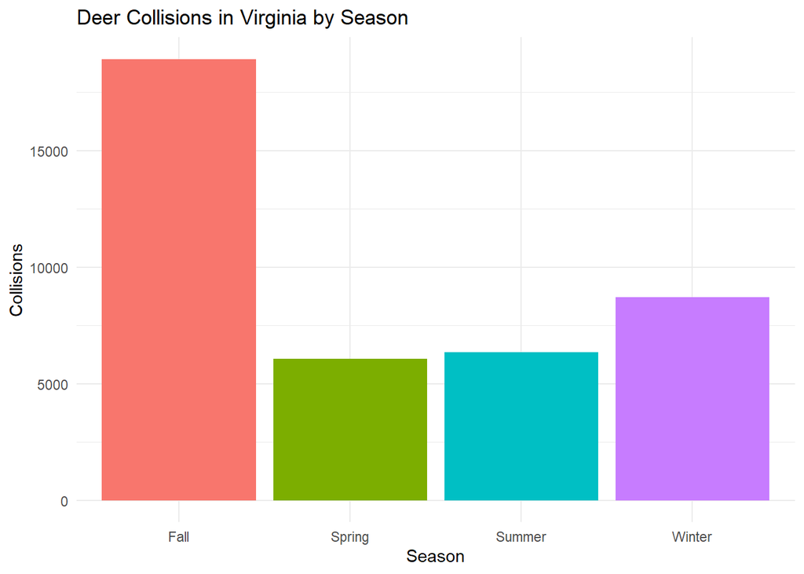

```r
# 4. Create a bar plot of collisions by season

va_collisions %>%
  mutate(month = lubridate::month(
    as.Date(
      date_time))) %>%
  mutate(Season =
           if_else(
             month > 2 & month < 6,
             "Spring",
             if_else(
               month > 5 & month < 9,
               "Summer",
               if_else(month > 8 & month < 12,
                       "Fall",
                       "Winter")) )) %>%
  as_tibble() %>%
  ggplot(aes(Season, fill = Season)) +
  geom_bar() +
  labs(y = "Collisions",
       title = "Deer Collisions in Virginia by Season") +
  theme_minimal() +
  theme(legend.position = "none")
```

5. **[1 point]** Generate a map showing the counties of Virginia with counties colored by the average number of collisions per year.

Using a mixture of code from questions 3 and 4, county data is appended to collisions information and year is extracted from date-time data. Collisions are then grouped twice, once to determine collisions in each year, and then to average these values. Finally, these data are plotted on a map of Virginia colored using the viridis palette.

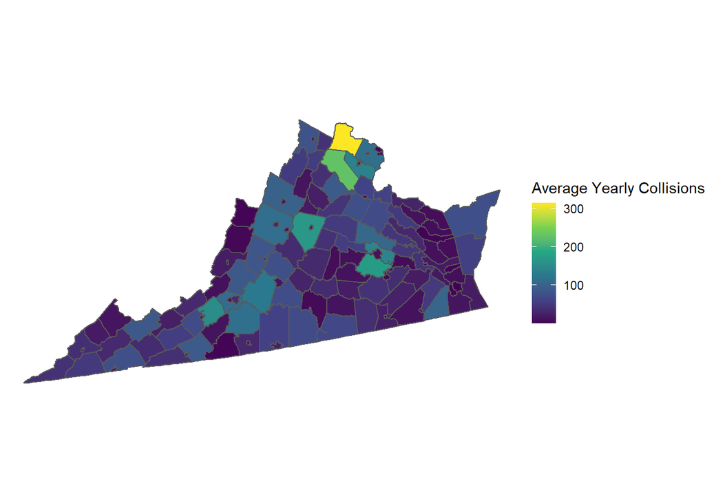

```r
# 5. Create a choropleth of Virginia counties
# by average collisions per year

va_shp %>%
  st_join(va_collisions) %>%
  mutate(year = lubridate::year(
    as.Date(date_time))) %>%
  group_by(STCOFIPS, year) %>%
  summarize(collisions =
              n()) %>%
  group_by(STCOFIPS) %>%
  summarize(avg_yearly_collisions =
              mean(collisions, na.rm = T)) %>%
  ggplot() +
  geom_sf(aes(fill = avg_yearly_collisions)) +
  scale_fill_continuous(type = "viridis") +
  theme_void() +
  labs(fill = "Average Yearly Collisions")
```

6. **[2 points]** Subset the NLCD raster to the extent and outline of Warren County. Generate a raster stack with two layers, forested/non-forested and developed/undeveloped land (see reference key below).

Matrices for converting forest and developed land data to binaries are initialized. These are then stored as a list and passed through a purrr::map function to extract forest and developed land data for Warren County. The resulting two layers are stored as a raster stack.

```r
# 6. Subset the raster to Warren County
# Generate a raster stack with two-layers: forested/non-forested &
# developed/undeveloped land

# Creates a matrix converting non-forest tiles to zero

forest_reclass <-
  tibble(
    from =
      va_land_cover %>%
      raster::values() %>%
      unique() %>%
      sort()) %>%
  mutate(
    to =
      if_else(from %in% 41:43, 1, 0)) %>%
  as.matrix()

# Creates a matrix converting non-developed tiles to zero

developed_reclass <-
  tibble(
    from =
      va_land_cover %>%
      raster::values() %>%
      unique() %>%
      sort()) %>%
  mutate(
    to =
      if_else(from %in% 21:24, 1, 0)) %>%
  as.matrix()

reclass_matrices <-
  list(forest_reclass, developed_reclass)

# Finds Warren County's STCOFIPS
warren_fips <- va_shp %>%
  filter(NAMELSAD == "Warren County") %>%
  pull(STCOFIPS) %>%
  unique()

# Creates the raster stack, with two rasters:
# one for forests and one for developed land in Warren County

warren_rasters <- raster::stack(
  reclass_matrices %>%
    purrr::map(
      ~ va_shp %>%
        filter(STCOFIPS == warren_fips) %>%
        raster::crop(va_land_cover, .) %>%
        raster::mask(va_shp %>%
                       filter(STCOFIPS == warren_fips)) %>%
        raster::reclassify(.x)))
```

7. **[2 points]** Using your raster stack from above, calculate the mean proportional cover for both forest and developed land within 200m of each incident, and report the average value per collision incident.

The raster stack of forests and developed land in Warren County is used to join two columns detailing the proportion of forest and developed land within 200 meters of each deer collision. The results are then summarized and average proportions of forest and developed land near collisions are returned.

```r
# 7. Report average forest and developed land within 200m of each incident

va_collisions %>%
  left_join(
    raster::extract(     # Determines average forested land near collision
      raster::subset(warren_rasters, 1),
      .,
      buffer = 200,    # distance (meters) from point
      fun = mean,    # average value within distance specified above
      na.rm = T,
      sp = T) %>%
      as_tibble() %>%
      select(c(event_id,
               proportion_forest = nlcd2016.1)) %>%
      filter(proportion_forest > 0),
    on = "event_id") %>%
  left_join(
    raster::extract(     # Determines average developed land near a collision
      raster::subset(warren_rasters, 2),
      .,
      buffer = 200,      # distance (meters) from point
      fun = mean,      # average value within distance specified above
      na.rm = T,
      sp = T) %>%
      as_tibble() %>%
      select(c(event_id,
               proportion_developed = nlcd2016.2)) %>%
      filter(proportion_developed > 0),
    on = "event_id") %>%
  as_tibble() %>%
  select(c(proportion_forest, proportion_developed)) %>%
  summarize(average_proportion_forest =
              mean(proportion_forest, na.rm = T),
            average_proportion_developed =
              mean(proportion_developed, na.rm = T))
```

```
## # A tibble: 1 x 2
##   average_proportion_forest average_proportion_developed
##                       <dbl>                        <dbl>
## 1                     0.391                        0.384
```

```r
# Clear any hidden connections

gc()

# Remove the unzipped homework folder

unlink(
  'data/raw/homework_data_deer_collisions',
  recursive = TRUE)
```

### Additional points alloted:

- R code parsimony **[1 point]**

## Hints

- As always, be careful about the coordinate reference system of your spatial objects!
- This R Markdown file does not contain and code blocks, you’ll have the put them in yourselves. Explore how I did it in the homework assignments.

## Extra credit

- **1 point extra credit**: Answer question 6 using a for loop or purrr::map() function.

## Submission

You will hand in a single R Markdown file – be sure that Markdown file knits properly. Your file will include all of the code used in data cleaning (provided in code chunks) and a written description of each step and why it was done. You will not hand in a .r script file for this assignment.

## Additional Information

Reference codes for NLCD Data: [link](https://www.mrlc.gov/data/legends/national-land-cover-database-2019-nlcd2019-legend).